# Week 05 - Information representation

## Higlighting specific nodes or links

This plot visualizes how far each city is from Leipzig in terms of network distance. A lavender-to-blue gradient is used, where cities closer to Leipzig appear darker and those further away appear lighter. The path distance to Leipzig is added as a vertex.label.

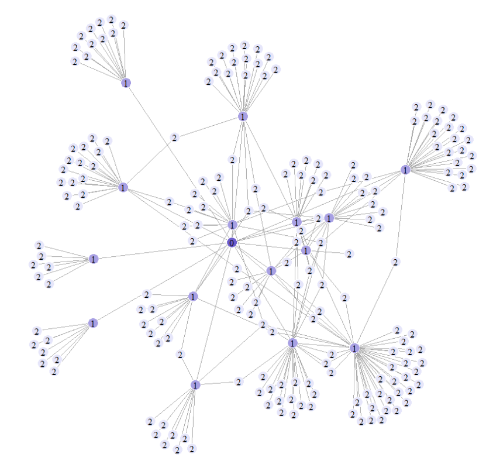

Distance from Leipzig

```r
lavender_palette <- colorRampPalette(c("#6A5ACD", "#E6E6FA"))  # purple to lavender
dist.from.Leipzig <- distances(twin_cities,
                               v = V(twin_cities)[name == "Leipzig"],
                               to = V(twin_cities),
                               weights = NA)

col <- lavender_palette(max(dist.from.Leipzig) + 1)
col <- col[dist.from.Leipzig + 1]

plot(twin_cities,
     vertex.color = col,
     vertex.label = dist.from.Leipzig,
     edge.arrow.size = 0.6,
     vertex.label.color = "black",
     vertex.label.size = 0.3)
```

This visualization highlights the shortest path between Leipzig and Kyoto to emphasize both the nodes and the edges involved in the path.

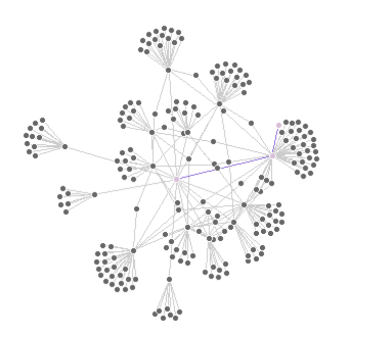

Path between Leipzig and Kyoto

```r
city_path <- shortest_paths(twin_cities,
                            from = V(twin_cities)[name == "Leipzig"],
                            to   = V(twin_cities)[name == "Kyoto"],
                            output = "both")

ecol <- rep("gray80", ecount(twin_cities))
ecol[unlist(city_path$epath)] <- "#9370DB"  # medium purple


vcol <- rep("gray40", vcount(twin_cities))
vcol[unlist(city_path$vpath)] <- "#D8BFD8"  # thistle (light purple)

plot(twin_cities,
     vertex.color = vcol,
     edge.color = ecol,
     edge.width = 0.1
     )
```

This figure highlights all edges that are directly connected to Leipzig. The city itself is shown in purple, and its incident connections are marked in blue.

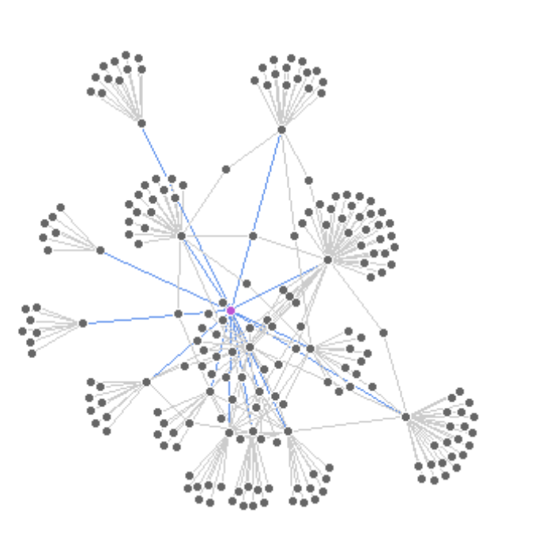

Edges from Leipzig

```r
inc.edges <- incident(twin_cities,
                      V(twin_cities)[name == "Leipzig"],
                      mode = "all")

ecol <- rep("gray80", ecount(twin_cities))
ecol[inc.edges] <- "#6495ED"  # cornflower blue

vcol <- rep("gray40", vcount(twin_cities))
vcol[V(twin_cities)$name == "Leipzig"] <- "#BA55D3"  # medium orchid

plot(twin_cities,
     vertex.color = vcol,
     edge.color = ecol)
```

This network highlights the immediate neighbors of Leipzig—cities directly connected by an outgoing edge.

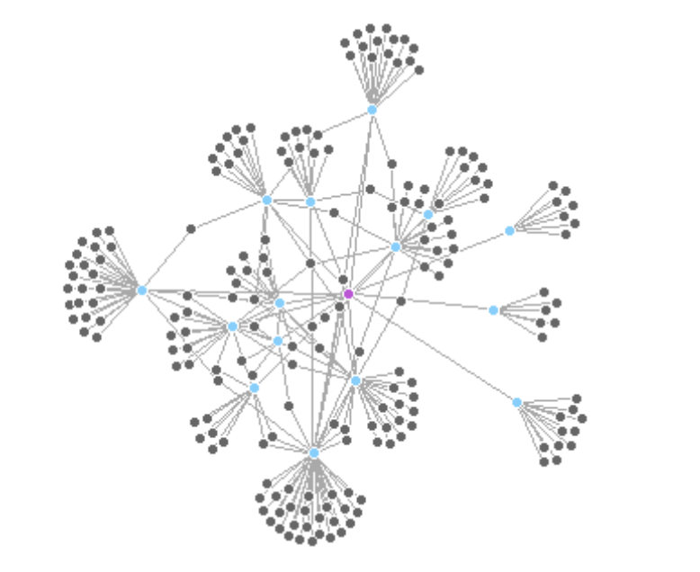

Node neighbors of Leipzig

```r
neigh.nodes <- neighbors(twin_cities,
                         V(twin_cities)[name == "Leipzig"],
                         mode = "out")

vcol <- rep("gray40", vcount(twin_cities))
vcol[neigh.nodes] <- "#87CEFA"  # light sky blue
vcol[V(twin_cities)$name == "Leipzig"] <- "#BA55D3"  # medium orchid

plot(twin_cities,
     vertex.color = vcol)
```

[figure not shown]

```r
# **Mark country groups (France and Japan) with lavender-blue tones**

france_nodes <- which(V(twin_cities)$countries == "France")
japan_nodes <- which(V(twin_cities)$countries == "Japan")

par(mfrow = c(1, 2))

plot(twin_cities,
     mark.groups = france_nodes,
     mark.col = "#E6E6FA",  # lavender
     mark.border = NA)

plot(twin_cities,
     mark.groups = list(france_nodes, japan_nodes),
     mark.col = c("#E6E6FA", "#B0C4DE"),  # lavender and light steel blue
     mark.border = NA)

dev.off()
```

You get the point ;)

# Plot visualisation in `ggraph`

The basic `ggraph()` plot adds edges and nodes using layers. Here we start with a default layout and basic layers. [Here you can find additional information on changeable parameters](https://ggraph.data-imaginist.com/reference/index.html).

```r
ggraph(twin_cities) +
  geom_edge_link() +    # Adds straight edges
  geom_node_point()     # Adds simple node points
```

You can customize the layout. Here we use `"gem"`, a force-directed layout similar to Fruchterman-Reingold, which gives a more organic structure to the network. You can use different edge and node geometries for various effects. `geom_edge_fan()` helps visualize overlapping edges, and you can control their appearance with color, width, and transparency.

```r
ggraph(twin_cities, layout = "gem") +
  geom_edge_fan(size = 1, color = "lightgray") +
  geom_node_point(size = 4, color = "lavender") +
  ggtitle("Twin Cities Network (GEM Layout)") +
  theme_void()
```

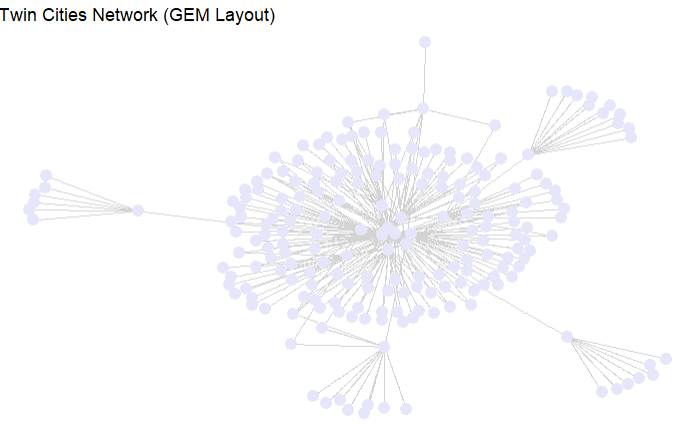

GGraph-Plot

You can also use layouts like `'linear'` to arrange nodes along a line, which is useful for timelines or flows. Here we use `geom_edge_arc()` to show curved connections.

```r
# Save high-resolution ggraph plot
p <- ggraph(twin_cities, layout = "linear") +
  geom_edge_arc(color = "#6495ED", width = 0.6) +
  geom_node_point(size = 1, color = "navy") +
  geom_node_text(aes(label = name),
                 nudge_y = -0.6,
                 vjust = 1.5,
                 angle = 45,
                 size = 1,
                 color = "navy") +
  theme_void()

# Save the plot
ggsave("Graphics/twin_cities_linear.png", plot = p,
       width = 10, height = 6, dpi = 300, units = "in")
```

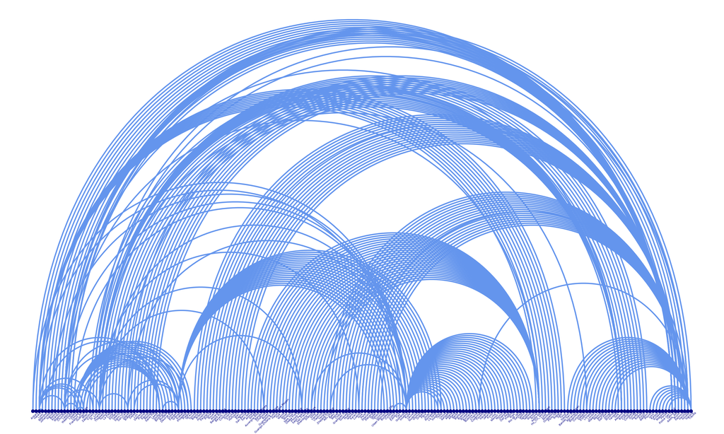

Linear Plot

You can also label nodes using their names. Here we use `geom_node_text()` with repelling to avoid overlapping labels.

```r
ggraph(twin_cities, layout = "fr") +
  geom_edge_link(color = "gray80") +
  geom_node_point(size = 5, color = "lavender") +  # medium orchid
  geom_node_text(aes(label = name), size = 3, color = "navy", repel = TRUE) +
  theme_void()
```

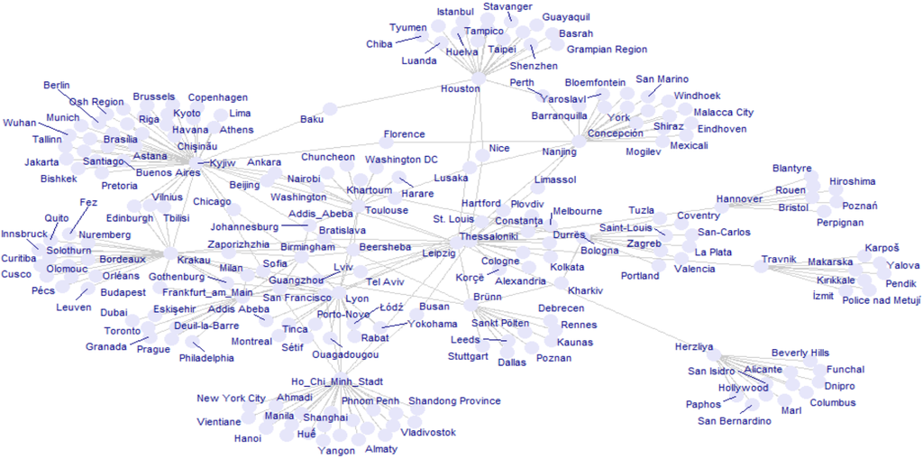

Repel labels

The `ggraph` package automatically generates legends when aesthetics like color or size are mapped to attributes. This makes interpreting your network plots easier without manual legend handling.

```r
# Create the network plot with ggraph
network_plot <- ggraph(twin_cities, layout = "fr") +
  geom_edge_link(alpha = 0.4) +
  geom_node_point(aes(color = countries), size = 2) +
  theme_minimal() +
  labs(title = "Twin Cities Network by Country") +
  theme(
    legend.position = "right",         # Keeps the legend on the right
    plot.margin = margin(r = 150),     # Adds margin space for legend
    legend.text = element_text(size = 3),  # Smaller text for legend
    legend.title = element_text(size = 2), # Smaller legend title text
    legend.key.size = unit(0.5, "cm")   # Smaller legend key size (color swatches)
  )

# Arrange the plot with the adjusted legend size
grid.arrange(network_plot, ncol = 1)
```

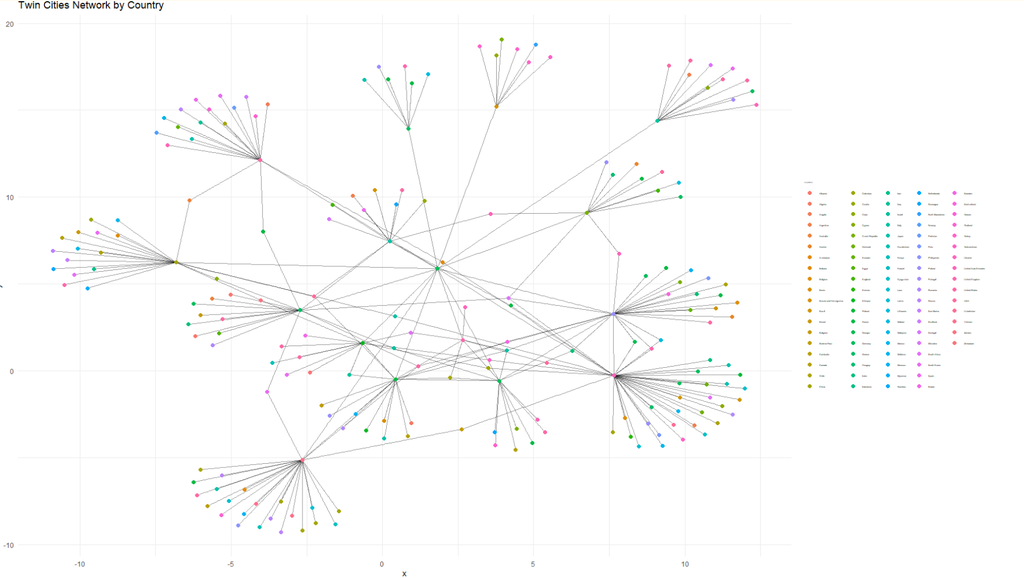

Color by country

## Other representatives

```r
# Convert the twin_cities network to an adjacency matrix (without edge weights, if not available)
netm <- as_adjacency_matrix(twin_cities, sparse = FALSE)

# Set the row and column names as the city names (or node names)
colnames(netm) <- V(twin_cities)$name
rownames(netm) <- V(twin_cities)$name

# Create a color palette for the heatmap
palf <- colorRampPalette(c("lavender", "lightblue"))

# Plot the heatmap
heatmap(netm,
        Rowv = NA,
        Colv = NA,
        col = palf(100),
        scale = "none",
        margins = c(10, 10),
        main = "Adjacency Matrix Heatmap of Twin Cities Network")
```

```r
# Calculate the degree distribution of the network
deg.dist <- degree_distribution(twin_cities, cumulative = TRUE, mode = "all")

# Plot the degree distribution
plot(x = 0:max(degree(twin_cities)),
     y = 1 - deg.dist,
     pch = 19,
     cex = 1.2,
     col = "lavender",
     xlab = "Degree",
     ylab = "Cumulative Frequency",
     main = "Degree Distribution of Twin Cities Network")
```

[figure not shown]

Degree distribution

[figure not shown]

Heatmap

```r
# Create a random network (Erdős–Rényi model)
set.seed(123)  # For reproducibility
random_net <- erdos.renyi.game(20, p = 0.2, directed = FALSE)  # 20 nodes, edge probability = 0.2

# Convert the random network to an adjacency matrix
netm <- as_adjacency_matrix(random_net, sparse = FALSE)

# Set row and column names as the node names (1, 2, ..., 20)
colnames(netm) <- V(random_net)$name
rownames(netm) <- V(random_net)$name

# Create a color palette for the heatmap
palf <- colorRampPalette(c("lavender", "lightblue"))

# Plot the heatmap of the adjacency matrix
heatmap(netm,
        Rowv = NA,
        Colv = NA,
        col = palf(100),
        scale = "none",
        margins = c(10, 10),
        main = "Adjacency Matrix Heatmap of Random Network")

# Calculate the degree distribution of the random network
deg.dist <- degree_distribution(random_net, cumulative = TRUE, mode = "all")

# Plot the degree distribution
plot(x = 0:max(degree(random_net)),
     y = 1 - deg.dist,
     pch = 19,
     cex = 1.2,
     col = "lavender",
     xlab = "Degree",
     ylab = "Cumulative Frequency",
     main = "Degree Distribution of Random Network")
```

# Network evolution visualisation

A lot of the times, networks are plottes as static networks at different timeframes

```r
g <- twin_cities


start_node <- "Leipzig"
V(g)$dist <- distances(g, v = start_node)[1,]


g_t1 <- induced_subgraph(g, vids = V(g)[V(g)$name == start_node])

ggraph(g_t1, layout = "fr") +
  geom_edge_link(color = "gray", alpha = 0.6) +
  geom_node_point(color = "lavender", size = 6) +
  geom_node_text(aes(label = name), vjust = -1, repel = TRUE, color = "darkblue") +
  ggtitle("D = 0: Leipzig") +
  theme_void() +
  theme(plot.title = element_text(hjust = 0.5, size = 12))

# D = 1: Leipzig + Neighbors
g_t2 <- induced_subgraph(g, vids = V(g)[V(g)$dist <= 1])

ggraph(g_t2, layout = "fr") +
  geom_edge_link(color = "gray", alpha = 0.6) +
  geom_node_point(color = "lavender", size = 6) +
  geom_node_text(aes(label = name), vjust = -1, repel = TRUE, color = "darkblue") +
  ggtitle("D = 1: Leipzig + Neighbors") +
  theme_void() +
  theme(plot.title = element_text(hjust = 0.5, size = 12))

# D = 2: Leipzig + Neighbors of Neighbors
g_t3 <- induced_subgraph(g, vids = V(g)[V(g)$dist <= 2])

ggraph(g_t3, layout = "fr") +
  geom_edge_link(color = "gray", alpha = 0.6) +
  geom_node_point(color = "lavender", size = 6) +
  geom_node_text(aes(label = name), vjust = -1, repel = TRUE, color = "darkblue") +
  ggtitle("D = 2: Leipzig + Neighbors of Neighbors") +
  theme_void() +
  theme(plot.title = element_text(hjust = 0.5, size = 12))
```

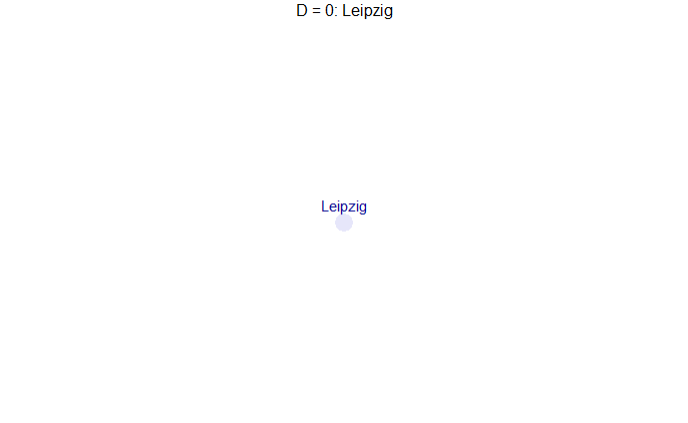

Leipzig

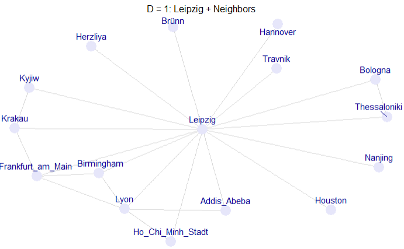

Leipzig

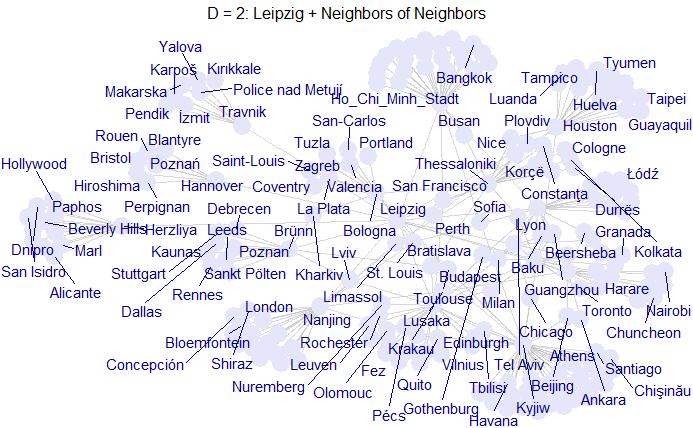

Leipzig

```r
# Set the starting node (Leipzig)
start_node <- "Leipzig"

# Calculate distance from Leipzig for all nodes
distances_from_leipzig <- distances(g, v = start_node)[1,]
V(g)$distance <- distances_from_leipzig  # Store the distances as a vertex attribute

# Create a list of graphs for each distance level (time)
max_dist <- max(V(g)$distance, na.rm = TRUE)  # Maximum distance

# Create a list to store subgraphs at each time step
subgraphs <- lapply(0:max_dist, function(d) {
  # Create a subgraph that includes nodes with distance <= d
  nodes_in_time <- V(g)[V(g)$distance <= d]
  induced_subgraph(g, vids = nodes_in_time)
})

# Create an animated plot using ggraph
p <- ggraph(g, layout = "fr") +
  geom_edge_link(aes(alpha = 0.3), show.legend = FALSE) +
  geom_node_point(aes(color = distance), size = 5) +
  geom_node_text(aes(label = name), vjust = -1) +
  transition_states(V(g)$distance, transition_length = 1, state_length = 100) +
  labs(title = "Twin City Growth from Leipzig: t = {closest_state}") +
  ease_aes('cubic-in-out')

# Animate the graph over time
animation <- animate(p, nframes = (max_dist + 1) * 10, width = 800, height = 600)
anim_save("Graphics/twin_city_growth.gif", animation = animation)
```

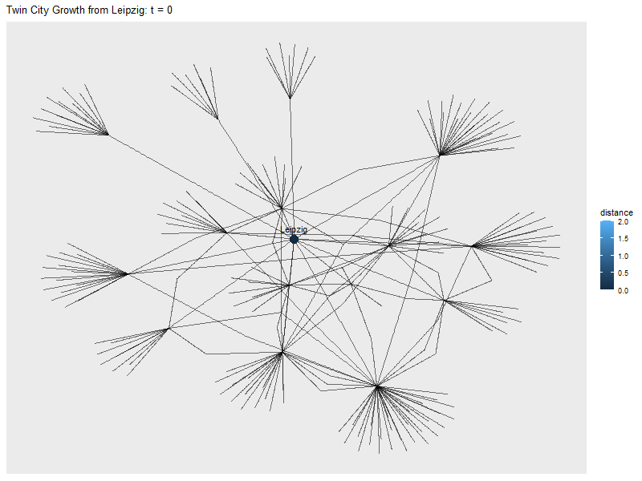

Growth Gif

or we can just create a shiny-App with a slider

```r
library(shiny)



ui <- fluidPage(
  sliderInput("t", "Time Step", min = 0, max = 2, value = 0, step = 1),
  plotOutput("networkPlot")
)

server <- function(input, output, session) {
  output$networkPlot <- renderPlot({
    vids <- V(g)[V(g)$dist <= input$t]
    g_sub <- induced_subgraph(g, vids = vids)

    ggraph(g_sub, layout = "fr") +
      geom_edge_link(aes(alpha = 0.3), show.legend = FALSE) +
      geom_node_point(aes(color = distance), size = 5) +
      geom_node_text(aes(label = name), vjust = -1) +
      ggtitle(paste("Network at time =", input$t))
  })
}

shinyApp(ui, server)
```

# Interactive visualisation with `networkD3`

To create an interactive network visualization with networkD3, you first need to convert your igraph network into two data frames: one for nodes and one for edges (links). The nodes should include a unique id and optionally attributes like group or size, while the links should include source and target indices starting from 0 (not 1).

Once the data is prepared, use forceNetwork() to build the visualization, specifying node and edge attributes, and finally save it as an HTML file using htmlwidgets::saveWidget(). This allows zooming, dragging, and exploring the network interactively in a browser.

```r
# Extract links and nodes for visualization
links <- as.data.frame(get.edgelist(twin_cities))
nodes <- data.frame(
  id = 1:vcount(twin_cities),
  name = V(twin_cities)$name,
  countries = V(twin_cities)$countries
)


# Ensure node IDs are numeric and start from 0
links.d3 <- data.frame(from = as.numeric(factor(links$V1)) - 1,
                       to = as.numeric(factor(links$V2)) - 1)

# Add a Nodesize column (you can use an actual attribute here, like degree, if needed)
nodes.d3 <- data.frame(idn = factor(nodes$name, levels = nodes$name), nodes)
nodes.d3$Nodesize <- rep(6, nrow(nodes.d3))  # Add a constant size for each node




# Save as a standalone HTML file
htmlwidgets::saveWidget(
  forceNetwork(Links = links.d3, Nodes = nodes.d3, Source = "from", Target = "to",
               NodeID = "name", Group = "countries", linkWidth = 1,
               linkColour = "#afafaf", fontSize = 12, zoom = TRUE, legend = FALSE,
               Nodesize = "Nodesize", opacity = 0.8, charge = -300,
               width = 800, height = 600),
  "Graphics/network_plot_interactive.html", selfcontained = TRUE
)
```

[interactive chart not shown]

# Exercise

The **Bali-network** shows the interactions inside the *Jemaah Ismlamiyah* terrorist group, which conducted an attack in Bali in the year of 2002 (Koschade 2007).

You can load the network like this:

```r
library(intergraph)
#install.packages("devtools")
#devtools::install_github("DougLuke/UserNetR")
library(UserNetR)

data(Bali)
Bali <- asIgraph(Bali)

help(Bali)
```

The network consists of 17 nodes (the terrorists) and 63 edges (their interactions). Next to the names, their roles in the group are saved as node attributes. The intensity of the interaction is saved as an edge attribute (See `help(Bali)`).

1. Plot the network so that the role is displayed as the node label. You can also change the size of the node.

```r
vertex.attributes(Bali)

V(Bali)$label <- V(Bali)$role

plot(Bali,
     vertex.size = 20,
     vertex.color = "lightblue",
     edge.color = "lightblue")
```

2. Define the color for each node, so that the color resembles the respective role.

```r
library(RColorBrewer)
my_colors <- brewer.pal(5,"Blues")
my_colors[factor(V(Bali)$role)]

E(Bali)$color <- "lightblue"

V(Bali)$color <- my_colors[factor(V(Bali)$role)]
plot(Bali,vertex.size=20)
```

3. Change the shape of the Commanders (CT) to a rectangle.

```r
V(Bali)$shape <- "circle"
V(Bali)[role == "CT"]$shape <- "rectangle"
plot(Bali,vertex.size=20)
```

4. Use the edge attribute IC, so that an edge is thicker if there is higher interaction between terrorists.

```r
E(Bali)$width <- E(Bali)$IC
plot(Bali, vertex.size=20)
```

5. Create an interactive plot, where, when you hover over the node, the role is shown.

```r
# Extract links and nodes for visualization
# Extract edge list and include weights
edges <- get.edgelist(Bali)
weights <- E(Bali)$IC  # assuming edge weights are stored as 'weight'

links <- data.frame(
  from = edges[, 1],
  to = edges[, 2],
  value = weights  # 'value' is the standard name used by networkD3 for link width
)

# Convert node names to zero-based indices for networkD3
links.d3 <- data.frame(
  from = as.numeric(factor(links$from)) - 1,
  to = as.numeric(factor(links$to)) - 1,
  value = links$value
)


nodes <- data.frame(
  id = 1:vcount(Bali),
  name = V(Bali)$vertex.names,
  role = V(Bali)$role
)


# Full role name in data.frame
nodes <- nodes %>%
  mutate(role = recode(role,
                            "CT" = "Command Team",
                            "OA" = "Operational Assistant",
                            "BM" = "Bomb Maker",
                            "SB" = "Suicide Bomber",
                            "TL" = "Team Lima"
                            )
         )




# Add a Nodesize column (you can use an actual attribute here, like degree, if needed)
nodes.d3 <- data.frame(idn = factor(nodes$name, levels = nodes$name), nodes)
nodes.d3$Nodesize <- rep(6, nrow(nodes.d3))  # Add a constant size for each node





forceNetwork(Links = links.d3, Nodes = nodes.d3, Source = "from", Target = "to",
               NodeID = "role", Group = "role", linkWidth = (links.d3$value*3),
               linkColour = "#afafaf", fontSize = 12, zoom = TRUE, legend = TRUE,
               Nodesize = "Nodesize", opacity = 0.8, charge = -300,
               width = 800, height = 600)
```

## References

Koschade, Stuart Andrew. 2007. “The Internal Dynamics of Terrorist Cells: A Social Network Analysis of Terrorist Cells in an Australian Context.” PhD thesis, Queensland University of Technology.

Ognyanova, Katya. 2024. “Static and Dynamic Network Visualization with R.” https://kateto.net/network-visualization/; Katya Ognyanova.

Rawlings, Craig M., Daniel A. McFarland, James Moody, and Jeffrey A. Smith, eds. 2023. “How Are Social Network Data Visualized?” In *Network Analysis: Integrating Social Network Theory, Method, and Application with R*, 88–114. Structural Analysis in the Social Sciences. Cambridge: Cambridge University Press. https://doi.org/10.1017/9781139794985.006.

## Copyright

© 2026 Leonie Steinbrinker